# R Notebook

2024-04-15

1. Explain the data collection process (10 points)

Data collection: https://www.kaggle.com/datasets/laotse/credit-risk-dataset?resource=download

Dependent variable: loan_status Independent variables: 1) person_age  
2) person_income  
3) person_emp_length  
4) loan_grade  
5) loan_amnt  
6) loan_int_rate 7) loan_percent_income 8) cb_person_default_on_file

Independent variables: 1) person_age:(INTEGER) Age of the individual applying for the loan. 2) person_income:(INTEGER) Annual income of the individual. 3) person_emp_length:(FLOAT) Employment length of the individual in years. 4) loan_grade:(CHARACTER) The grade assigned to the loan based on the creditworthiness of the borrower. A: The borrower has a high creditworthiness, indicating low risk. B: The borrower is relatively low-risk, but not as creditworthy as Grade A. C: The borrower’s creditworthiness is moderate. D: The borrower is considered to have higher risk compared to previous grades. E: The borrower’s creditworthiness is lower, indicating a higher risk. F: The borrower poses a significant credit risk. G: The borrower’s creditworthiness is the lowest, signifying the highest risk. 5) loan_amnt:(INTEGER)The loan amount requested by the individual. 6) loan_int_rate:(FLOAT) The interest rate associated with the loan. 7) loan_percent_income:(FLOAT) The percentage of income represented by the loan amount. 8) cb_person_default_on_file:(INTEGER)Historical default of the individual as per credit bureau records. a. Y: The individual has a history of defaults on their credit file. b. N: The individual does not have any history of defaults. Dependent variable: 1) loan_status:(INTEGER) Loan status, where 1 indicates did not recieve loan and 0 indicates loan recieved.

Various factors influence loan status among borrowers, including personal financial stability, employment status, credit history, and loan terms. By analysing such factors I can provide valuable insights to the lenders to assess the creditworthiness of applicants and tailor loan terms accordingly.

Understanding the factors that contribute to loan status enables individuals to understand and take proactive measures to mitigate risks that affects if they will get a loan or not.

#Question: Does the loan grade define if a person will recieve loan or not?

```r
library(readr)
library(cluster)
library(readr)
library(factoextra)
library(magrittr)
library(NbClust)
dataset<- read_csv("C:/Users/rusha/Downloads/Multivariate/credit_risk_dataset.csv/credit_risk_dataset.csv")
str(dataset)
```

```
## spc_tbl_ [498 × 10] (S3: spec_tbl_df/tbl_df/tbl/data.frame)
##  $ person_age                : num [1:498] 22 21 25 23 24 21 26 24 24 21 ...
##  $ loan_status               : num [1:498] 1 0 1 1 1 1 1 1 1 1 ...
##  $ person_income             : num [1:498] 59000 9600 9600 65500 54400 ...
##  $ person_emp_length         : num [1:498] 12 5 1 4 8 2 8 5 8 6 ...
##  $ loan_amnt                 : num [1:498] 35000 1000 5500 35000 35000 2500 35000 35000 35000 1600 ...
##  $ loan_int_rate             : num [1:498] 16 11.1 12.9 15.2 14.3 ...
##  $ loan_percent_income       : num [1:498] 0.59 0.1 0.57 0.53 0.55 0.25 0.45 0.44 0.42 0.16 ...
##  $ cb_person_cred_hist_length: num [1:498] 3 2 3 2 4 2 3 4 2 3 ...
##  $ loan_grade                : chr [1:498] "D" "B" "C" "C" ...
##  $ cb_person_default_on_file : chr [1:498] "Y" "N" "N" "N" ...
##  - attr(*, "spec")=
##   .. cols(
##   ..   person_age = col_double(),
##   ..   loan_status = col_double(),
##   ..   person_income = col_double(),
##   ..   person_emp_length = col_double(),
##   ..   loan_amnt = col_double(),
##   ..   loan_int_rate = col_double(),
##   ..   loan_percent_income = col_double(),
##   ..   cb_person_cred_hist_length = col_double(),
##   ..   loan_grade = col_character(),
##   ..   cb_person_default_on_file = col_character()
##   .. )
##  - attr(*, "problems")=<externalptr>
```

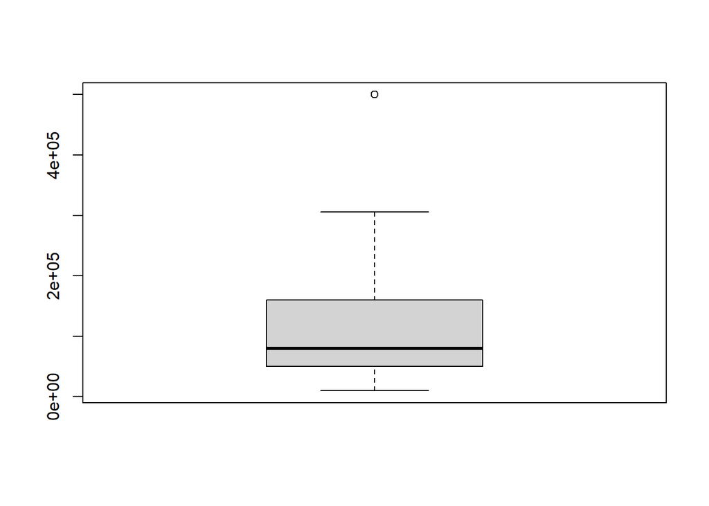

```r
boxplot(dataset$person_income)
```

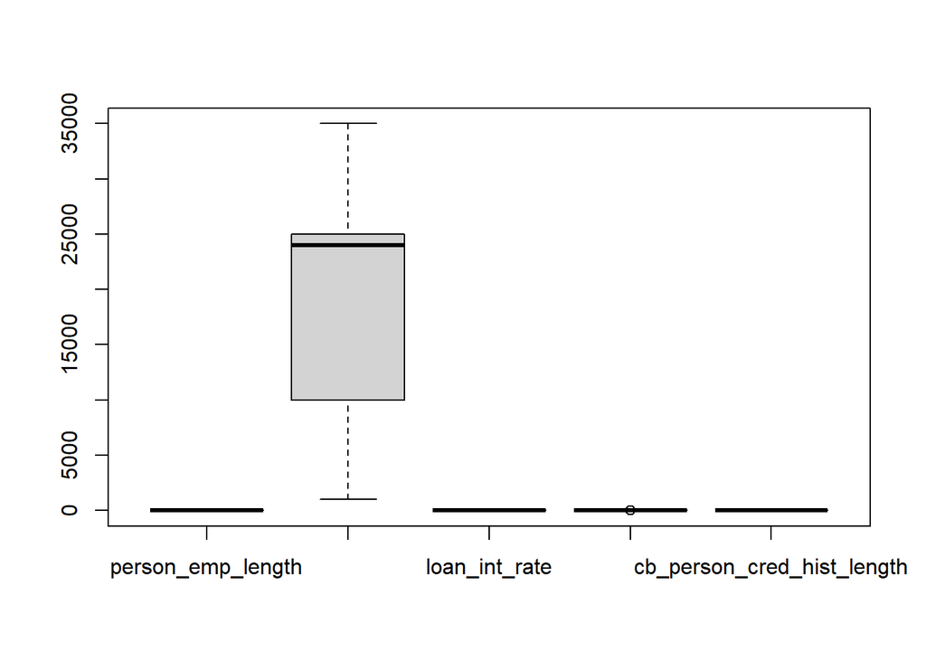

```r
boxplot(dataset[,4:8])
```

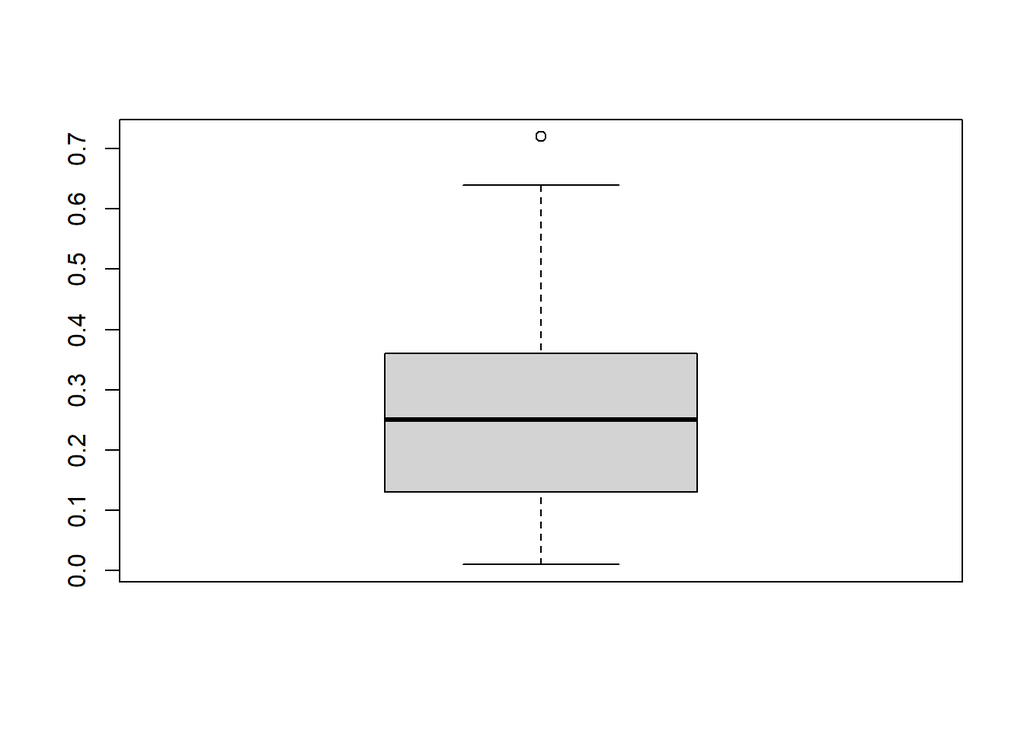

```r
boxplot(dataset$loan_percent_income)
```

#Insights:

Boxplot of person income and loan percent income shows an outlier. The median for loan amount is close to 24000, with bottom edge of 10000 and top edge of 25000. The median for loan percent income is close to 0.25, with bottom edge of 0.1 and top edge of 0.35.

[figure not shown]

```r
stars(dataset,labels = dataset$loan_status)
```

#Correlation matrix

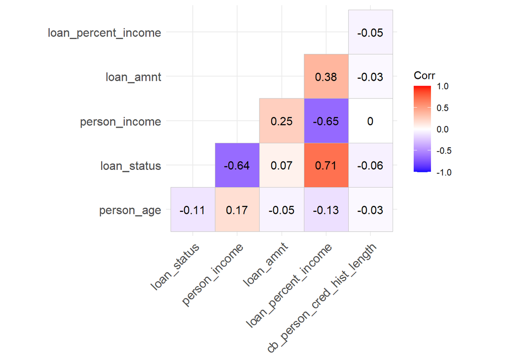

```r
library(ggcorrplot)
correlation_matrix<- cor(dataset[,0:8])
ggcorrplot(correlation_matrix,type = "lower", lab = TRUE)
```

#Insights:

By looking at the correlation matrix we can understand the magnitude and direction of relationship between two variables.Closer the value to 1 the stronger the relationship. Negative value indicates that the direction is opposite.

## As the income increases the percentage of income represented by loan amount decreases.

1. Here, value -0.65 for person_income vs loan_percent_income indicates a moderate-strong relationship and an inverse relationship.One variable increases, the other variable decreases, and vice versa.

## High loan_status i.e a person did not recieve loan, the loan percent of income also increases.

2. Value 0.71 for loan_status vs loan_percent_income indicates a strong relationship and a positive correlation.

## People borrow a big loan and then the loan takes off a higher percentage of their income.– Not good.

3. Value 0.38 for loan_amnt vs loan_percent_income indicates a moderate-strong relationship and a positive correlation.

# Popular age group between loan borrowers

```r
# MAX AND MIN AGE
max_age <- max(dataset$person_age, na.rm = TRUE)
min_age <- min(dataset$person_age, na.rm = TRUE)
cat("Maximum Age:", max_age, "\n")
```

```
## Maximum Age: 144
```

```r
cat("Minimum Age:", min_age, "\n")
```

```
## Minimum Age: 21
```

```r
# People with an age between x and y
age_group <- function(arr, dataset) {
  for (i in seq_along(arr[-1])) {
    age_min <- arr[i] + 1
    age_max <- arr[i + 1]
    num_people <- sum(dataset$person_age >= age_min & dataset$person_age < age_max, na.rm = TRUE)
    cat("Age between", age_min, "and", age_max, ": Number of people", num_people, "\n")
  }
}

age_group(c(0, 21, 23, 25, 27), dataset)
```

```
## Age between 1 and 21 : Number of people 0
## Age between 22 and 23 : Number of people 72
## Age between 24 and 25 : Number of people 110
## Age between 26 and 27 : Number of people 76
```

2. Exploratory Data Analysis and Visualizations (50 points) # Univariate visualizations

## What is the typical loan amount that most people borrow?

1. Density plot of Loan Amount

```r
library(scales)
```

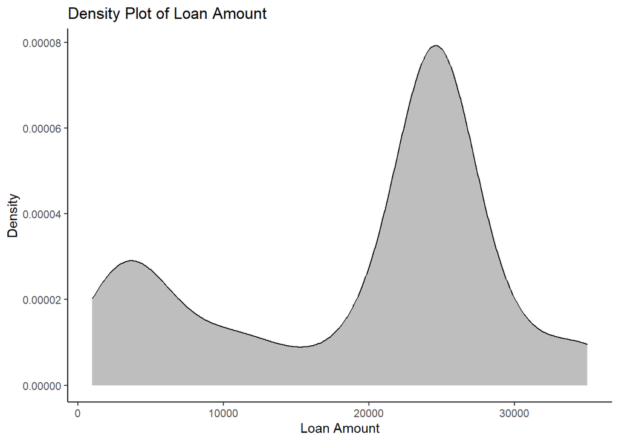

```r
density_loan_amount <- ggplot(dataset, aes(x = loan_amnt)) +
  geom_density(fill = "grey") + labs(title = "Density Plot of Loan Amount") +
  scale_y_continuous(labels = comma)+
  xlab("Loan Amount") + ylab("Density")+theme_classic()

print(density_loan_amount)
```

The plot is continuous and widely spread. A wider spread suggests a greater range of loan amounts.

## Does grade define the loan status?

2. Bar plot of Loan Grade

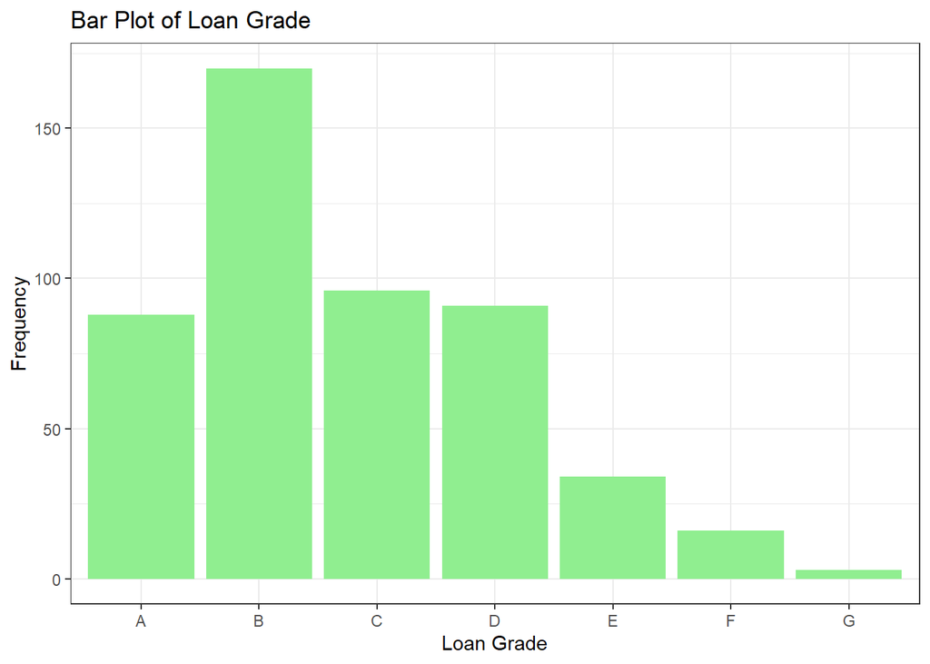

```r
bar_loan_grade <- ggplot(dataset, aes(x = loan_grade)) +
  geom_bar(fill = "lightgreen") +
  labs(title = "Bar Plot of Loan Grade") +
  xlab("Loan Grade") +
  ylab("Frequency")+theme_bw()

print(bar_loan_grade)
```

#Insights:

Looking at the bar plot, we can understand Grade B is the highest in frequency while grade G is the least. Further, this means that the number of borrowers who are relatively low-risk, but not as creditworthy as Grade A are the most in count.

The borrower’s creditworthiness is moderate, that is grade C is more than the borrowers, grade A, who has the highest creditworthiness.

#People with Grade A,B,C,D are higher than E,F,G

#Bivariate Visuals

1)Scatter Plot- Matrix

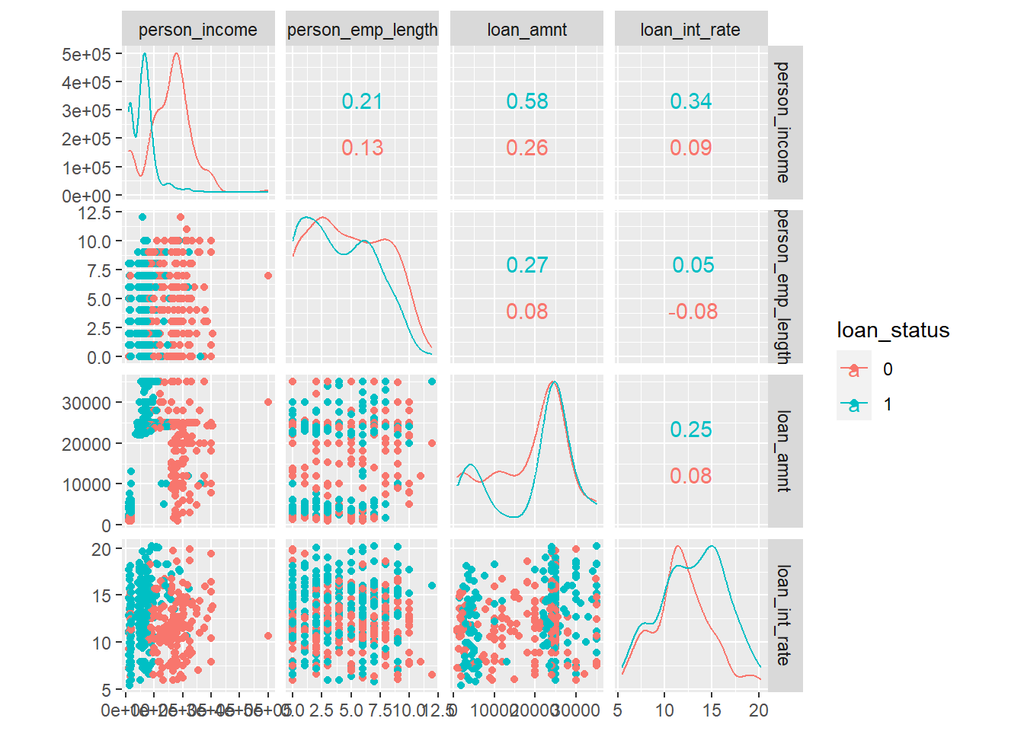

```r
library(GGally)
ggscatmat(dataset, columns=3:6, color="loan_status")
```

The length of employement has a positive correlation with income of a person.

2. Boxplot of Loan grade vs Loan amount

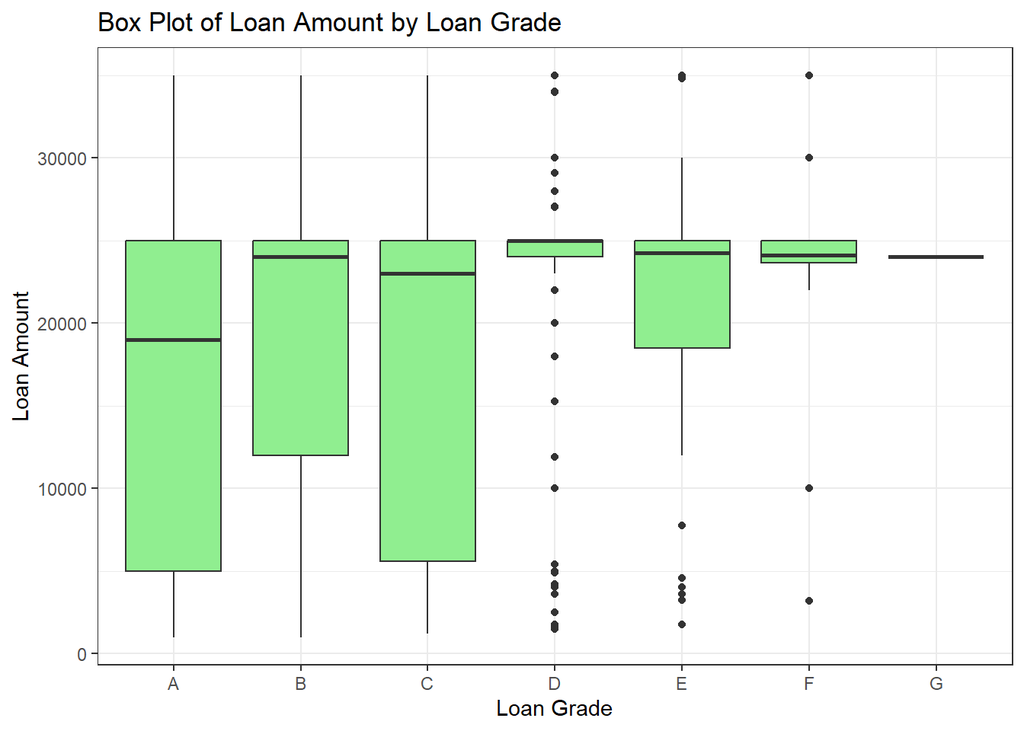

```r
boxplot_loan_grade_amount <- ggplot(dataset, aes(x = loan_grade, y = loan_amnt)) +
  geom_boxplot(fill = "lightgreen") +
  labs(title = "Box Plot of Loan Amount by Loan Grade") +
  xlab("Loan Grade") +
  ylab("Loan Amount") + theme_bw()

print(boxplot_loan_grade_amount)
```

#Insights: The plot shows, that the borrowers with loan grade D has most number of outliers when compared with the loan amount requested by them. or We can say that the a person with loan grade D asks for random amount of loans. This might also define why the borrower’s is considered to have higher risk of creditworthiness.

3. Scatter plot of Loan amount vs loan percent income

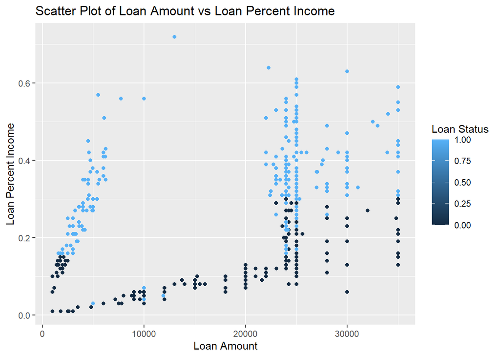

```r
scatter_plot <- ggplot(dataset, aes(x = loan_amnt, y = loan_percent_income, color=loan_status )) +
  geom_point() +  # Add points
  labs(x = "Loan Amount", y = "Loan Percent Income", title = "Scatter Plot of Loan Amount vs Loan Percent Income", color = "Loan Status")
plot(scatter_plot)
```

By looking at the plot we can say, the status of loan getting accepted does not depend upon the loan amount asked. People who got a loan have a loan which is of less percentage of their income.

#Scatter Plot of Loan amount vs loan percent income with loan grades colored

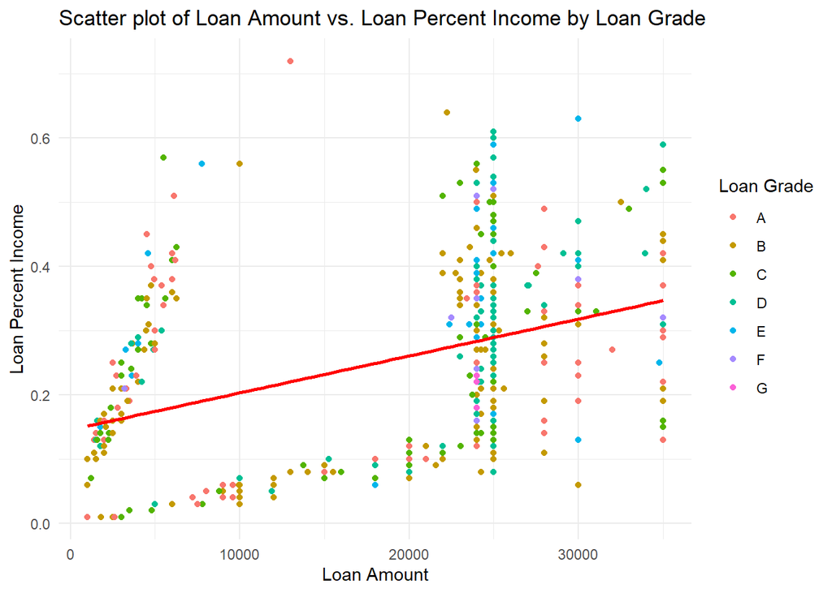

```r
ggplot(dataset, aes(x = loan_amnt, y = loan_percent_income, color = loan_grade)) +
  geom_point() +
  geom_smooth(method = "lm", se = FALSE, color = "red") +
  labs(title = "Scatter plot of Loan Amount vs. Loan Percent Income by Loan Grade",
       x = "Loan Amount", y = "Loan Percent Income", color = "Loan Grade") +
  theme_minimal()
```

#Insights:

Points are more densely populated between loan amount 0-10000 and 22000-30000.

Having a high loan percent income does not always corresponds to having a high loan amount. Borrowers who have requested Loan amounts of 5000-7000 also corresponds to high percentage of borrowers income. The same for borrowers requesting loan about of 25000 or greater.

```r
library(lattice)
```

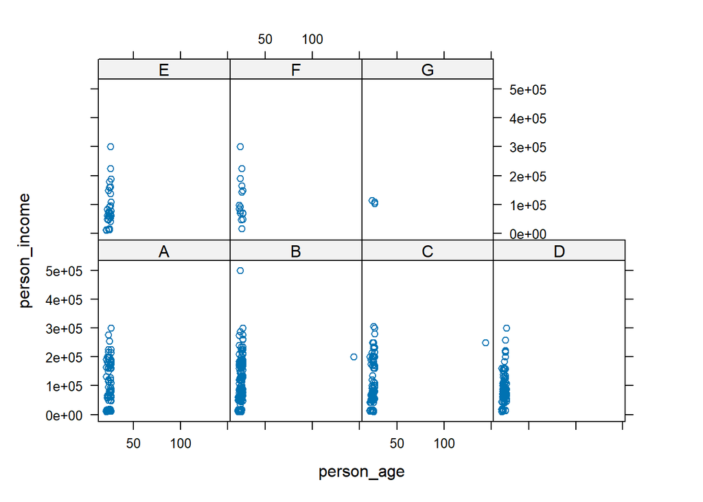

```r
xyplot(person_income ~ person_age | loan_grade, data = dataset)
```

Statistics test

```r
options(scipen = 999) # To suppress scientific notation

dataset_clean <- na.omit(dataset)
datascale <- dist(scale(dataset_clean[,c("loan_status","person_income","loan_amnt","loan_percent_income")],center = FALSE))
as.dist(round(as.matrix(datascale), 2)[1:20, 1:20])
```

```
##       1    2    3    4    5    6    7    8    9   10   11   12   13   14   15
## 2  2.66
## 3  1.40 2.09
## 4  0.21 2.55 1.42
## 5  0.14 2.58 1.39 0.11
## 6  1.91 1.44 1.09 1.81 1.83
## 7  0.49 2.43 1.50 0.29 0.38 1.71
## 8  0.53 2.41 1.52 0.32 0.42 1.70 0.04
## 9  0.60 2.39 1.55 0.40 0.49 1.69 0.11 0.07
## 10 2.14 1.36 1.40 2.02 2.04 0.31 1.89 1.87 1.85
## 11 0.64 2.38 1.56 0.43 0.53 1.68 0.15 0.11 0.04 1.84
## 12 1.52 1.80 0.41 1.48 1.47 0.68 1.49 1.49 1.51 0.99 1.51
## 13 0.80 2.34 1.65 0.59 0.69 1.67 0.30 0.27 0.19 1.81 0.16 1.56
## 14 0.99 2.31 1.77 0.78 0.88 1.69 0.50 0.47 0.39 1.79 0.35 1.65 0.20
## 15 1.72 1.88 2.26 1.60 1.66 2.17 1.47 1.45 1.42 2.24 1.41 2.16 1.37 1.35
## 16 4.11 4.05 4.55 3.99 4.09 4.29 3.81 3.78 3.73 4.27 3.71 4.42 3.60 3.46 3.12
## 17 1.75 1.89 2.29 1.63 1.68 2.18 1.49 1.47 1.44 2.25 1.43 2.18 1.38 1.35 0.05
## 18 0.95 2.27 1.71 0.74 0.83 1.63 0.45 0.42 0.35 1.74 0.31 1.59 0.17 0.13 1.36
## 19 1.04 2.32 1.80 0.83 0.93 1.70 0.55 0.51 0.44 1.80 0.40 1.67 0.25 0.05 1.34
## 20 2.13 1.36 1.40 2.01 2.04 0.31 1.88 1.86 1.84 0.01 1.83 0.99 1.80 1.78 2.23
##      16   17   18   19
## 2
## 3
## 4
## 5
## 6
## 7
## 8
## 9
## 10
## 11
## 12
## 13
## 14
## 15
## 16
## 17 3.07
## 18 3.57 1.36
## 19 3.42 1.35 0.17
## 20 4.26 2.24 1.73 1.79
```

Testing Statistics

Univariate analysis 1) Finding means of each column 2) Covariance matrix for all columns in the data 3) Mahalanobis distances for each observation: To identify outlier or observations that are unusual relative to the overall distribution of the data. The distance is also used in clustering algorithms, like k-means clustering.

```r
x<- dataset_clean[,c("loan_status","person_income","loan_amnt","loan_percent_income")]
x
```

| loan_status | person_income | loan_amnt | loan_percent_income |
| --- | --- | --- | --- |
| 1 | 59000 | 35000 | 0.59 |
| 0 | 9600 | 1000 | 0.10 |
| 1 | 9600 | 5500 | 0.57 |
| 1 | 65500 | 35000 | 0.53 |
| 1 | 54400 | 35000 | 0.55 |
| 1 | 9900 | 2500 | 0.25 |
| 1 | 77100 | 35000 | 0.45 |
| 1 | 78956 | 35000 | 0.44 |
| 1 | 83000 | 35000 | 0.42 |
| 1 | 10000 | 1600 | 0.16 |

[output cut: 431 more lines]

```r
dataset_cm <- colMeans(x)
dataset_cm
```

```
##         loan_status       person_income           loan_amnt loan_percent_income
##           0.5532880      104516.4058957       19726.5306122           0.2562812
```

Insights: Correlation Average Income: The average person’s income is approximately $104,516.41. Average Loan Amount: The average loan amount is approximately $19,726.53. Loan-to-Income Ratio: On average, loans represent about 25.63% of a person’s income.

```r
standardized_data <- scale(x)
dataset_S <- cov(standardized_data)
dataset_S
```

```
##                     loan_status person_income  loan_amnt loan_percent_income
## loan_status          1.00000000    -0.6371524 0.07794379           0.7151159
## person_income       -0.63715244     1.0000000 0.22357968          -0.6637858
## loan_amnt            0.07794379     0.2235797 1.00000000           0.3731563
## loan_percent_income  0.71511590    -0.6637858 0.37315626           1.0000000
```

without standardizing

```r
dataset_d <- apply(x, MARGIN = 1, function(x)t(x - dataset_cm) %*% solve(dataset_S) %*% (x - dataset_cm))
dataset_d
```

```
##   [1]  10022855058  25176169023  26360711118   7800459788  11769583690
##   [6]  25385691740   4549536402   4114460426   3247757352  25096412725
##  [11]   2860297397  25853219178   1331764427    358438065    318523992
##  [16] 518666422564    491014749   1703385567    297232868  24672506635
##  [21]   8833890532   2361169039   7757026563  24506394122   3721420634
##  [26]   6714884091  25286302763  24469893938   7458969750  24909463489
##  [31]  24322916234    474508894    969380658 135110724462 138719433571
##  [36]  24174853893  13162153446   7292978655   4269606051   7914979304
##  [41]  24174853893 129983612322 127093178474 137096035199 126591295410
##  [46] 131371128566   3029188631   6592675346   1609937618   3588118541
##  [51]   1218073595    695897675    485358563 111135413625 101298597198
##  [56]   1256917326   1658664177 103790235303  44771694006   5393291645
##  [61]  23925623400  77955796368  81145664515  82746853251  69448895577
##  [66]  24301154243   6623806234   2017471838  25108596651   1561562647
##  [71]  24608730957  24751804994   2354771684  72992275929  80256797070
```

[output cut: 74 more lines]

Distance Large distance = outlier / anomaly

Lets find out if the dataset follows a particular distribution/ is normally distributed? –Applying qqnorm to three variables: person_income, loan_amnt, and loan_percent_income

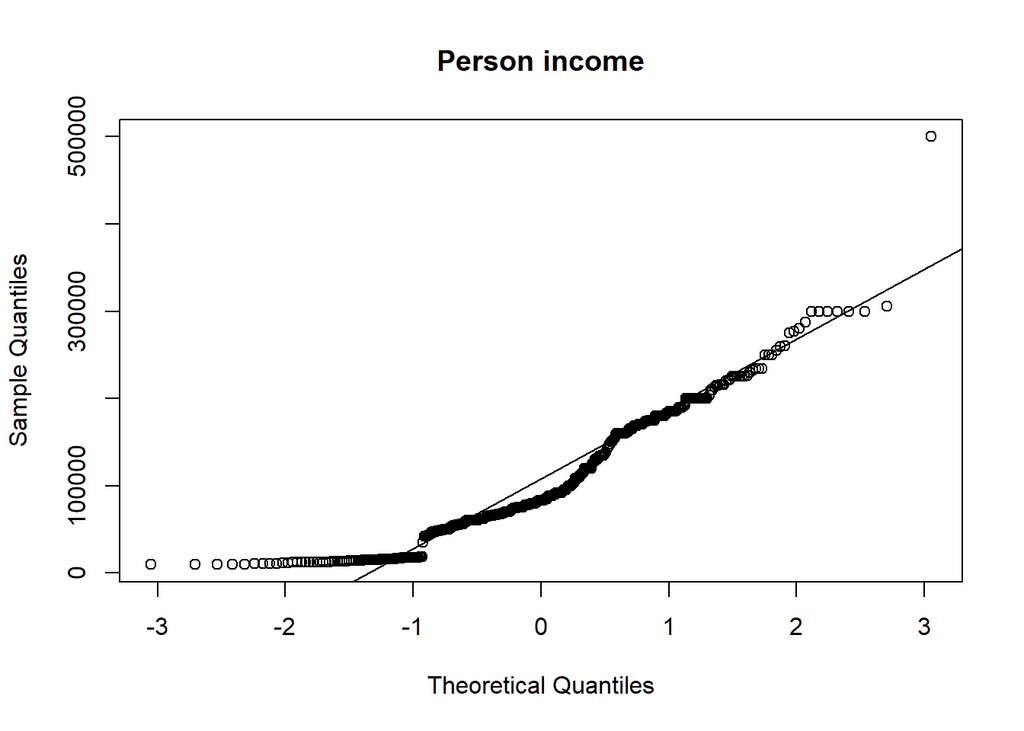

```r
qqnorm(dataset_clean$person_income, main = "Person income")
qqline(dataset_clean$person_income)
```

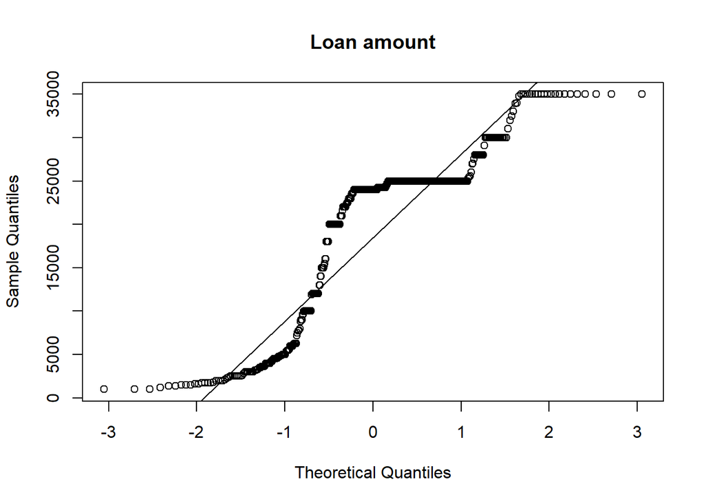

```r
qqnorm(dataset_clean$loan_amnt, main = "Loan amount")
qqline(dataset_clean$loan_amnt)
```

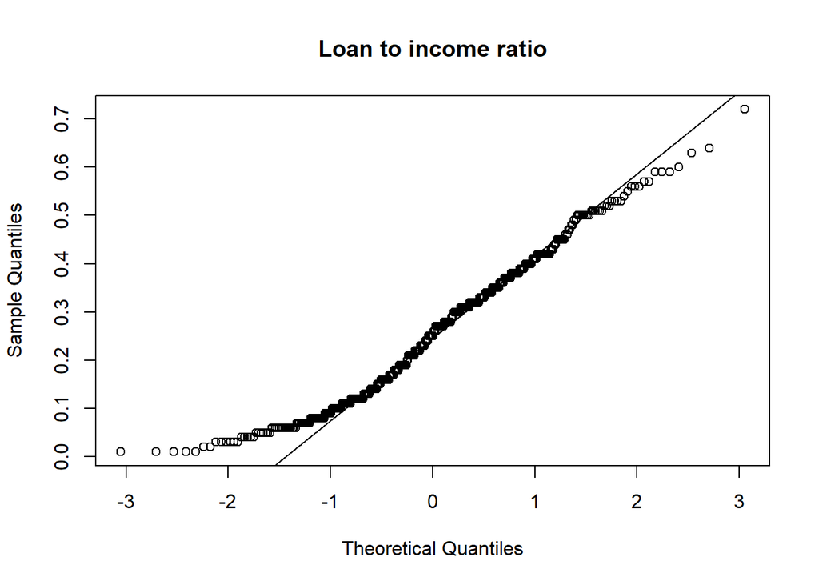

```r
qqnorm(dataset_clean$loan_percent_income, main = "Loan to income ratio")
qqline(dataset_clean$loan_percent_income)
```

Insight: #Person income is following the reference line at some points, while misses at some.

#Loan amount is not normally distributed for most points.

#Loan to income ratio is normally distributed for most points at the centre, while misses some points at the start and end.

Test to find equality of variances between 2 groups of loan status.

```r
var.test(dataset$loan_status==0, dataset$loan_status==1)
```

```
##
##  F test to compare two variances
##
## data:  dataset$loan_status == 0 and dataset$loan_status == 1
## F = 1, num df = 497, denom df = 497, p-value = 1
## alternative hypothesis: true ratio of variances is not equal to 1
## 95 percent confidence interval:
##  0.8385889 1.1924794
## sample estimates:
## ratio of variances
##                  1
```

Insight: p-value = 1, suggests that there is no significant difference in the variances between the two groups of loan status.

Performing t-test for each independent variable in the dataset, by comparing its means between two groups of loan status.

```r
with(data=dataset_clean,t.test(person_income[loan_status==0],person_income[loan_status==1],var.equal=TRUE))
```

```
##
##  Two Sample t-test
##
## data:  person_income[loan_status == 0] and person_income[loan_status == 1]
## t = 17.321, df = 439, p-value < 0.00000000000000022
## alternative hypothesis: true difference in means is not equal to 0
## 95 percent confidence interval:
##   83919.85 105402.06
## sample estimates:
## mean of x mean of y
## 156891.17  62230.22
```

```r
with(data=dataset_clean,t.test(person_emp_length[loan_status==0],person_emp_length[loan_status==1],var.equal=TRUE))
```

```
##
##  Two Sample t-test
##
## data:  person_emp_length[loan_status == 0] and person_emp_length[loan_status == 1]
## t = 2.7314, df = 439, p-value = 0.006561
## alternative hypothesis: true difference in means is not equal to 0
## 95 percent confidence interval:
##  0.224430 1.376094
## sample estimates:
## mean of x mean of y
##  4.771574  3.971311
```

```r
with(data=dataset_clean,t.test(loan_amnt[loan_status==0],loan_amnt[loan_status==1],var.equal=TRUE))
```

```
##
##  Two Sample t-test
##
## data:  loan_amnt[loan_status == 0] and loan_amnt[loan_status == 1]
## t = -1.6381, df = 439, p-value = 0.1021
## alternative hypothesis: true difference in means is not equal to 0
## 95 percent confidence interval:
##  -3286.6860   298.5224
## sample estimates:
## mean of x mean of y
##  18899.87  20393.95
```

```r
with(data=dataset_clean,t.test(loan_int_rate[loan_status==0],loan_int_rate[loan_status==1],var.equal=TRUE))
```

```
##
##  Two Sample t-test
##
## data:  loan_int_rate[loan_status == 0] and loan_int_rate[loan_status == 1]
## t = -4.4867, df = 439, p-value = 0.000009249
## alternative hypothesis: true difference in means is not equal to 0
## 95 percent confidence interval:
##  -1.9592103 -0.7656192
## sample estimates:
## mean of x mean of y
##  11.73853  13.10094
```

t-value is -4.48, signficant difference between the means of two groups. In opposite direction. p-value = 0.000009249, extremely low, strong evidence against null hypothesis.

```r
with(data=dataset_clean,t.test(loan_percent_income[loan_status==0],loan_percent_income[loan_status==1],var.equal=TRUE))
```

```
##
##  Two Sample t-test
##
## data:  loan_percent_income[loan_status == 0] and loan_percent_income[loan_status == 1]
## t = -21.435, df = 439, p-value < 0.00000000000000022
## alternative hypothesis: true difference in means is not equal to 0
## 95 percent confidence interval:
##  -0.2307358 -0.1919775
## sample estimates:
## mean of x mean of y
## 0.1393401 0.3506967
```

t-value is -21.43, strong signficant difference between the means of two groups. In opposite direction. p-value < 0.00000000000000022, extremely low, strong evidence against null hypothesis.

```r
with(data=dataset_clean,t.test(cb_person_cred_hist_length[loan_status==0],cb_person_cred_hist_length[loan_status==1],var.equal=TRUE))
```

```
##
##  Two Sample t-test
##
## data:  cb_person_cred_hist_length[loan_status == 0] and cb_person_cred_hist_length[loan_status == 1]
## t = 1.5837, df = 439, p-value = 0.114
## alternative hypothesis: true difference in means is not equal to 0
## 95 percent confidence interval:
##  -0.02992333  0.27823822
## sample estimates:
## mean of x mean of y
##  3.091371  2.967213
```

Multivariate analysis: Hotelling’s T-squared test/ extension of the univariate t-test to multidimensional data.

```r
library(Hotelling)
```

```r
t2test <- hotelling.test(person_income + person_emp_length + loan_amnt + loan_int_rate + loan_percent_income + cb_person_cred_hist_length ~ loan_status, data = dataset_clean )
cat("T2 statistic =", t2test$stat[[1]],"\n")
```

```
## T2 statistic = 645.0108
```

```r
print(t2test)
```

```
## Test stat:  645.01
## Numerator df:  6
## Denominator df:  434
## P-value:  0
```

Insight: T2 statistic of 645, measures how much the average values of multiple variables differ between the two groups in loan status. Larger T2 value indicates a greater difference. There is strong distinction between the groups based on the combination of variables being analyzed.

p-value = 0 suggests strong evidence against the null hypothesis. Thus indicating significant differences between the group means in the multivariate space. That is there is something affecting and we cannot accept the null hypothesis.

Levene’s test–to find if the variance of independent variables differ significantly between different groups of loan status.

```r
datastand <- round(scale(dataset_clean[,3:8]),2)
datastand
```

```
##        person_income person_emp_length loan_amnt loan_int_rate
##   [1,]         -0.62              2.49      1.60          1.09
##   [2,]         -1.28              0.22     -1.96         -0.42
##   [3,]         -1.28             -1.08     -1.49          0.12
##   [4,]         -0.53             -0.11      1.60          0.85
##   [5,]         -0.68              1.19      1.60          0.55
##   [6,]         -1.28             -0.76     -1.81         -1.65
##   [7,]         -0.37              1.19      1.60         -0.02
##   [8,]         -0.35              0.22      1.60         -0.43
##   [9,]         -0.29              1.19      1.60         -1.11
##  [10,]         -1.28              0.54     -1.90          0.69
##  [11,]         -0.26              0.54      1.60         -0.66
##  [12,]         -1.28             -0.76     -1.60         -1.19
##  [13,]         -0.13             -0.76      1.60         -1.42
##  [14,]          0.05             -0.11      1.60          1.82
```

[output cut: 883 more lines]

```r
attach(dataset_clean)
dataL <- datastand[loan_status==0,]
dataL
```

```
##        person_income person_emp_length loan_amnt loan_int_rate
##   [1,]         -1.28              0.22     -1.96         -0.42
##   [2,]          0.14             -0.76      1.60         -1.42
##   [3,]          5.35              0.87      1.08         -0.57
##   [4,]          0.21             -1.40      1.60         -1.42
##   [5,]          0.78             -0.76      1.60         -1.54
##   [6,]          0.44              1.52      1.58          1.32
##   [7,]         -1.26             -1.40     -1.91         -1.61
##   [8,]         -1.26             -1.40     -1.92         -0.98
##   [9,]          0.21             -0.76      1.29         -1.81
##  [10,]          2.72             -0.76      0.47          0.42
##  [11,]          2.64              1.84     -1.25          0.31
##  [12,]          2.64              1.84      0.03         -1.42
##  [13,]          2.64             -1.08      0.47          2.14
##  [14,]          2.64              1.52     -1.02         -0.65
```

[output cut: 381 more lines]

Vector containing the median values of each column in the subset of data

```r
dataNL <- datastand[dataset_clean$loan_status==1,]
vecmedianL <- apply(dataL, 2, median)
vecmedianL
```

```
##              person_income          person_emp_length
##                       0.82                       0.22
##                  loan_amnt              loan_int_rate
##                       0.35                      -0.31
##        loan_percent_income cb_person_cred_hist_length
##                      -0.93                      -0.03
```

The absolute deviations of each element in the data Subtracting the median values from the elements of datadef and then taking the absolute value of the differences.

```r
vecmedianNL <- apply(dataNL,2,median)
matabsdevL <- abs(dataL - matrix(rep(vecmedianL,nrow(dataL)),nrow=nrow(dataL),byrow=TRUE))
matabsdevNL <- round(abs(dataNL - matrix(rep(vecmedianNL,nrow(dataNL)),nrow=nrow(dataNL), byrow=TRUE)),2)

matabsdevNL
```

```
##        person_income person_emp_length loan_amnt loan_int_rate
##   [1,]          0.05              2.60      1.06          0.85
##   [2,]          0.71              0.97      2.03          0.12
##   [3,]          0.04              0.00      1.06          0.61
##   [4,]          0.11              1.30      1.06          0.31
##   [5,]          0.71              0.65      2.35          1.89
##   [6,]          0.20              1.30      1.06          0.26
##   [7,]          0.22              0.33      1.06          0.67
##   [8,]          0.28              1.30      1.06          1.35
##   [9,]          0.71              0.65      2.44          0.45
##  [10,]          0.31              0.65      1.06          0.90
##  [11,]          0.71              0.65      2.14          1.43
##  [12,]          0.44              0.65      1.06          1.66
##  [13,]          0.62              0.00      1.06          1.58
##  [14,]          0.40              0.98      1.06          2.16
```

[output cut: 475 more lines]

```r
matabsdev.all <- rbind(matabsdevL, matabsdevNL)
matabsdev.all <- data.frame(dataset_clean$loan_status, matabsdev.all)

matabsdev.all
```

| dataset_clean.loan_status | person_income | person_emp_length | loan_amnt | loan_int_rate | loan_percent_income | cb_person_cred_hist_length |
| --- | --- | --- | --- | --- | --- | --- |
| 1 | 2.10 | 0.00 | 2.31 | 0.11 | 0.13 | 1.22 |
| 0 | 0.68 | 0.98 | 1.25 | 1.11 | 1.23 | 1.22 |
| 1 | 4.53 | 0.65 | 0.73 | 0.26 | 0.40 | 0.00 |
| 1 | 0.61 | 1.62 | 1.25 | 1.11 | 1.16 | 1.22 |
| 1 | 0.04 | 0.98 | 1.25 | 1.23 | 0.68 | 1.22 |
| 1 | 0.38 | 1.30 | 1.23 | 1.63 | 0.89 | 1.22 |
| 1 | 2.08 | 1.62 | 2.26 | 1.30 | 0.14 | 0.00 |
| 1 | 2.08 | 1.62 | 2.27 | 0.67 | 0.07 | 0.00 |
| 1 | 0.61 | 0.98 | 0.94 | 1.50 | 1.02 | 1.22 |
| 1 | 1.90 | 0.98 | 0.12 | 0.73 | 0.27 | 0.00 |

[output cut: 431 more lines]

T-test for each independent variable

```r
t.test(matabsdev.all$person_income[matabsdev.all$dataset_clean.loan_status == 0], matabsdev.all$person_income[matabsdev.all$dataset_clean.loan_status == 1], alternative="less",var.equal=TRUE)
```

```
##
##  Two Sample t-test
##
## data:  matabsdev.all$person_income[matabsdev.all$dataset_clean.loan_status == 0] and matabsdev.all$person_income[matabsdev.all$dataset_clean.loan_status == 1]
## t = -2.4729, df = 439, p-value = 0.00689
## alternative hypothesis: true difference in means is less than 0
## 95 percent confidence interval:
##         -Inf -0.04372805
## sample estimates:
## mean of x mean of y
## 0.4649239 0.5960656
```

```r
t.test(matabsdev.all$person_emp_length[matabsdev.all$dataset_clean.loan_status == 0], matabsdev.all$person_emp_length[matabsdev.all$dataset_clean.loan_status == 1], alternative="less",var.equal=TRUE)
```

```
##
##  Two Sample t-test
##
## data:  matabsdev.all$person_emp_length[matabsdev.all$dataset_clean.loan_status == 0] and matabsdev.all$person_emp_length[matabsdev.all$dataset_clean.loan_status == 1]
## t = -1.3537, df = 439, p-value = 0.08826
## alternative hypothesis: true difference in means is less than 0
## 95 percent confidence interval:
##        -Inf 0.01423819
## sample estimates:
## mean of x mean of y
## 0.8176142 0.8830328
```

```r
t.test(matabsdev.all$loan_amnt[matabsdev.all$dataset_clean.loan_status == 0], matabsdev.all$loan_amnt[matabsdev.all$dataset_clean.loan_status == 1], alternative="less",var.equal=TRUE)
```

```
##
##  Two Sample t-test
##
## data:  matabsdev.all$loan_amnt[matabsdev.all$dataset_clean.loan_status == 0] and matabsdev.all$loan_amnt[matabsdev.all$dataset_clean.loan_status == 1]
## t = 0.08818, df = 439, p-value = 0.5351
## alternative hypothesis: true difference in means is less than 0
## 95 percent confidence interval:
##       -Inf 0.1368112
## sample estimates:
## mean of x mean of y
## 0.7288325 0.7218852
```

```r
t.test(matabsdev.all$loan_percent_income[matabsdev.all$dataset_clean.loan_status == 0], matabsdev.all$loan_percent_income[matabsdev.all$dataset_clean.loan_status == 1], alternative="less",var.equal=TRUE)
```

```
##
##  Two Sample t-test
##
## data:  matabsdev.all$loan_percent_income[matabsdev.all$dataset_clean.loan_status == 0] and matabsdev.all$loan_percent_income[matabsdev.all$dataset_clean.loan_status == 1]
## t = 0.2401, df = 439, p-value = 0.5948
## alternative hypothesis: true difference in means is less than 0
## 95 percent confidence interval:
##        -Inf 0.08189301
## sample estimates:
## mean of x mean of y
## 0.5453299 0.5349180
```

Insight: p-value for personal_income is < 0.05. Thus, rejecting the null hypothesis.

Statistical tests to compare the mean absolute deviations of certain variables between loan not recieved and loan recieved, helping to understand if there are significant differences between the groups.

```r
matstand.all <- data.frame(dataset_clean$loan_status, datastand)
matstand.all
```

| dataset_clean.loan_status | person_income | person_emp_length | loan_amnt | loan_int_rate | loan_percent_income | cb_person_cred_hist_length |
| --- | --- | --- | --- | --- | --- | --- |
| 1 | -0.62 | 2.49 | 1.60 | 1.09 | 2.27 | -0.03 |
| 0 | -1.28 | 0.22 | -1.96 | -0.42 | -1.06 | -1.25 |
| 1 | -1.28 | -1.08 | -1.49 | 0.12 | 2.13 | -0.03 |
| 1 | -0.53 | -0.11 | 1.60 | 0.85 | 1.86 | -1.25 |
| 1 | -0.68 | 1.19 | 1.60 | 0.55 | 2.00 | 1.19 |
| 1 | -1.28 | -0.76 | -1.81 | -1.65 | -0.04 | -1.25 |
| 1 | -0.37 | 1.19 | 1.60 | -0.02 | 1.32 | -0.03 |
| 1 | -0.35 | 0.22 | 1.60 | -0.43 | 1.25 | 1.19 |
| 1 | -0.29 | 1.19 | 1.60 | -1.11 | 1.11 | -1.25 |
| 1 | -1.28 | 0.54 | -1.90 | 0.69 | -0.65 | -0.03 |

[output cut: 431 more lines]

```r
colnames(matstand.all) <- colnames(dataset_clean[2:8])
t2testsparr <- hotelling.test(person_income+person_emp_length+loan_amnt +loan_int_rate+loan_percent_income ~ loan_status,data=matstand.all)
cat("T2 statistic =",t2testsparr$stat[[1]],"\n")
```

```
## T2 statistic = 642.1736
```

```r
#library(car)
#data_loan <- dataset_clean$loan_status
#leveneTest(person_income ~ data_loan, data=dataset_clean)
```

```r
#leveneTest(loan_amnt ~ data_loan, data=dataset_clean)
```

```r
#leveneTest(loan_percent_income ~ data_loan, data=dataset_clean)
```

# 3) Application of different MVA models (10 points)

## # PCA

```r
var_data <- dataset_clean[,2:8]
#cor(var_data[-1])
correlation_matrix <- cor(var_data[-1])
rounded_correlation_matrix <- round(correlation_matrix, 2)
rounded_correlation_matrix
```

```
##                            person_income person_emp_length loan_amnt
## person_income                       1.00              0.21      0.22
## person_emp_length                   0.21              1.00      0.14
## loan_amnt                           0.22              0.14      1.00
## loan_int_rate                       0.01             -0.03      0.19
## loan_percent_income                -0.66             -0.11      0.37
## cb_person_cred_hist_length          0.01             -0.07     -0.01
##                            loan_int_rate loan_percent_income
## person_income                       0.01               -0.66
## person_emp_length                  -0.03               -0.11
## loan_amnt                           0.19                0.37
## loan_int_rate                       1.00                0.10
## loan_percent_income                 0.10                1.00
## cb_person_cred_hist_length         -0.06               -0.05
##                            cb_person_cred_hist_length
## person_income                                    0.01
## person_emp_length                               -0.07
## loan_amnt                                       -0.01
## loan_int_rate                                   -0.06
## loan_percent_income                             -0.05
## cb_person_cred_hist_length                       1.00
```

```r
data_pca <- prcomp(var_data[,-1],scale=TRUE)
data_pca
```

```
## Standard deviations (1, .., p=6):
## [1] 1.3237063 1.1761473 1.0053511 0.9847198 0.8688897 0.3593131
##
## Rotation (n x k) = (6 x 6):
##                                    PC1        PC2          PC3        PC4
## person_income               0.64034330 -0.3138390 -0.134467761 -0.1174681
## person_emp_length           0.25407870 -0.3797222  0.283359661  0.5692846
## loan_amnt                  -0.14358983 -0.7206012 -0.239465840  0.1708283
## loan_int_rate              -0.14021033 -0.4177543 -0.117433232 -0.7236089
## loan_percent_income        -0.69518677 -0.1841387 -0.003424594  0.2254558
## cb_person_cred_hist_length  0.04292855  0.1721172 -0.911306503  0.2418550
##                                    PC5         PC6
## person_income               0.29451844  0.61060962
## person_emp_length          -0.62190997  0.01026889
## loan_amnt                   0.42127076 -0.44285501
## loan_int_rate              -0.51781513  0.01701462
## loan_percent_income         0.04406016  0.65576289
## cb_person_cred_hist_length -0.28096977  0.02480760
```

```r
summary(data_pca)
```

```
## Importance of components:
##                          PC1    PC2    PC3    PC4    PC5     PC6
## Standard deviation     1.324 1.1761 1.0054 0.9847 0.8689 0.35931
## Proportion of Variance 0.292 0.2306 0.1685 0.1616 0.1258 0.02152
## Cumulative Proportion  0.292 0.5226 0.6910 0.8527 0.9785 1.00000
```

1. Decide how many Principal Components (PCs) you want to keep and why (2 points) Answer: I want to keep PC1 PC2 and PC3, here is why PC1: highest standard deviation: captures the most variability in data: 29.2% of the total variance is captured PC2: high standard deviation: captures the most variability in data: 23.06% of the total variance is captured PC3: high standard deviation: captures 16.85% of the total variance: cumulative of PC1, PC2 and PC3 is 69.1%.

PC4 to PC6 captures significantly less proportions of total variance.

```r
(eigen_data <- data_pca$sdev^2)
```

```
## [1] 1.7521984 1.3833225 1.0107308 0.9696730 0.7549693 0.1291059
```

Insight: We consider retaining principal components with eigenvalues greater than 1.

```r
names(eigen_data) <- paste("PC",1:6,sep="")
eigen_data
```

```
##       PC1       PC2       PC3       PC4       PC5       PC6
## 1.7521984 1.3833225 1.0107308 0.9696730 0.7549693 0.1291059
```

```r
sumlambdas <- sum(eigen_data)
sumlambdas
```

```
## [1] 6
```

```r
propvar <- eigen_data/sumlambdas
propvar
```

```
##        PC1        PC2        PC3        PC4        PC5        PC6
## 0.29203307 0.23055376 0.16845514 0.16161216 0.12582822 0.02151765
```

```r
cumvar_data <- cumsum(propvar)
cumvar_data
```

```
##       PC1       PC2       PC3       PC4       PC5       PC6
## 0.2920331 0.5225868 0.6910420 0.8526541 0.9784824 1.0000000
```

```r
matlambdas <- rbind(sqrt(eigen_data),propvar,cumvar_data)
rownames(matlambdas) <- c("Eigenvalues","Prop. variance","Cum. prop. variance")
round(matlambdas,4)
```

```
##                        PC1    PC2    PC3    PC4    PC5    PC6
## Eigenvalues         1.3237 1.1761 1.0054 0.9847 0.8689 0.3593
## Prop. variance      0.2920 0.2306 0.1685 0.1616 0.1258 0.0215
## Cum. prop. variance 0.2920 0.5226 0.6910 0.8527 0.9785 1.0000
```

```r
summary(data_pca)
```

```
## Importance of components:
##                          PC1    PC2    PC3    PC4    PC5     PC6
## Standard deviation     1.324 1.1761 1.0054 0.9847 0.8689 0.35931
## Proportion of Variance 0.292 0.2306 0.1685 0.1616 0.1258 0.02152
## Cumulative Proportion  0.292 0.5226 0.6910 0.8527 0.9785 1.00000
```

2. Explain the variate representation each PCs

```r
data_pca$rotation
```

```
##                                    PC1        PC2          PC3        PC4
## person_income               0.64034330 -0.3138390 -0.134467761 -0.1174681
## person_emp_length           0.25407870 -0.3797222  0.283359661  0.5692846
## loan_amnt                  -0.14358983 -0.7206012 -0.239465840  0.1708283
## loan_int_rate              -0.14021033 -0.4177543 -0.117433232 -0.7236089
## loan_percent_income        -0.69518677 -0.1841387 -0.003424594  0.2254558
## cb_person_cred_hist_length  0.04292855  0.1721172 -0.911306503  0.2418550
##                                    PC5         PC6
## person_income               0.29451844  0.61060962
## person_emp_length          -0.62190997  0.01026889
## loan_amnt                   0.42127076 -0.44285501
## loan_int_rate              -0.51781513  0.01701462
## loan_percent_income         0.04406016  0.65576289
## cb_person_cred_hist_length -0.28096977  0.02480760
```

```r
print(data_pca)
```

```
## Standard deviations (1, .., p=6):
## [1] 1.3237063 1.1761473 1.0053511 0.9847198 0.8688897 0.3593131
##
## Rotation (n x k) = (6 x 6):
##                                    PC1        PC2          PC3        PC4
## person_income               0.64034330 -0.3138390 -0.134467761 -0.1174681
## person_emp_length           0.25407870 -0.3797222  0.283359661  0.5692846
## loan_amnt                  -0.14358983 -0.7206012 -0.239465840  0.1708283
## loan_int_rate              -0.14021033 -0.4177543 -0.117433232 -0.7236089
## loan_percent_income        -0.69518677 -0.1841387 -0.003424594  0.2254558
## cb_person_cred_hist_length  0.04292855  0.1721172 -0.911306503  0.2418550
##                                    PC5         PC6
## person_income               0.29451844  0.61060962
## person_emp_length          -0.62190997  0.01026889
## loan_amnt                   0.42127076 -0.44285501
## loan_int_rate              -0.51781513  0.01701462
## loan_percent_income         0.04406016  0.65576289
## cb_person_cred_hist_length -0.28096977  0.02480760
```

Insight: PC1 positively correlated with person_income person_emp_length and cb_person_cred_hist_length, thus PC1 captures information about the overall financial status, employment length, and credit history. loan_percent_income has a strong negative correlation with PC1, thus higher loan amounts relative to income are associated with lower values of PC1.

Similarily, PC2 is positively correlated with cb_person_cred_hist_length, strong negative correlation with loan_ammt and negatively correlated with all the other columns. PC3 is positively correlated with person_emp_length, strong negative correlation with cb_person_cred_hist_length and negatively with all other columns.

```r
data_pca$x
```

```
##                PC1          PC2          PC3             PC4          PC5
##   [1,] -1.72248642 -2.783374217  0.294393486  1.479646245412 -1.511569424
##   [2,]  0.25880743  1.889934762  1.893746464 -0.299535348049 -0.820508977
##   [3,] -2.38245272  1.441427023  0.227762758 -0.329236080609 -0.292998525
##   [4,] -2.06048594 -1.857972783  0.688415076 -0.219176600355  0.580073453
##   [5,] -1.77500105 -1.785150399 -1.112208992  1.372629284009 -0.797387072
##   [6,] -0.54424337  2.473316745  1.721220380  0.296252046649  0.536959546
##   [7,] -1.07810212 -1.727594566  0.027430687  1.301695431130 -0.098419420
##   [8,] -1.15307509 -0.974322224 -1.315602498  1.316844422282  0.378267899
##   [9,] -0.78519066 -1.470928582  1.256550150  1.737891139158  0.821632595
##  [10,] -0.05135686  1.390101594  0.726474790 -0.522133062379 -1.894620361
##  [11,] -0.84446075 -0.990198373 -1.207097018  1.611374211387  0.309841529
##  [12,] -1.58315919  1.879268043  1.612151467  0.305495389893  0.447323442
##  [13,] -0.89644803 -0.590844657  0.720374545  0.757086658649  2.225383860
##  [14,] -0.73073302 -1.763945174 -1.721872703 -0.724919660042 -0.503582426
```

[output cut: 869 more lines]

```r
#Identify the score by the loan status
datatyp_pca <- cbind(data.frame(loan_status),data_pca$x)
datatyp_pca
```

| loan_status | PC1 | PC2 | PC3 | PC4 | PC5 | PC6 |
| --- | --- | --- | --- | --- | --- | --- |
| 1 | -1.72248642 | -2.783374217 | 0.294393486 | 1.479646245412 | -1.511569424 | 0.4462615280 |
| 0 | 0.25880743 | 1.889934762 | 1.893746464 | -0.299535348049 | -0.820508977 | -0.6470227796 |
| 1 | -2.38245272 | 1.441427023 | 0.227762758 | -0.329236080609 | -0.292998525 | 1.2652996517 |
| 1 | -2.06048594 | -1.857972783 | 0.688415076 | -0.219176600355 | 0.580073453 | 0.1713951979 |
| 1 | -1.77500105 | -1.785150399 | -1.112208992 | 1.372629284009 | -0.797387072 | 0.2376946391 |
| 1 | -0.54424337 | 2.473316745 | 1.721220380 | 0.296252046649 | 0.536959546 | -0.0765100037 |
| 1 | -1.07810212 | -1.727594566 | 0.027430687 | 1.301695431130 | -0.098419420 | -0.0606198199 |
| 1 | -1.15307509 | -0.974322224 | -1.315602498 | 1.316844422282 | 0.378267899 | -0.0764957743 |
| 1 | -0.78519066 | -1.470928582 | 1.256550150 | 1.737891139158 | 0.821632595 | -0.1943869753 |
| 1 | -0.05135686 | 1.390101594 | 0.726474790 | -0.522133062379 | -1.894620361 | -0.3515951226 |

[output cut: 431 more lines]

```r
# Means of scores for all the PC's classified by loan status
tabmeansPC <- aggregate(datatyp_pca[,2:7],by=list(loan_status=dataset_clean$loan_status),mean)
tabmeansPC
```

| loan_status | PC1 | PC2 | PC3 | PC4 | PC5 | PC6 |
| --- | --- | --- | --- | --- | --- | --- |
| 0 | 1.0913824 | 0.04362689 | -0.08007141 | -0.006724547 | 0.1446998 | -0.05085008 |
| 1 | -0.8811571 | -0.03522335 | 0.06464782 | 0.005429245 | -0.1168273 | 0.04105519 |

Mean scores of each principal component for default vs non-default groups.

```r
tabfmeans <- t(tabmeansPC[,-1])
tabfmeans
```

```
##             [,1]         [,2]
## PC1  1.091382441 -0.881157135
## PC2  0.043626893 -0.035223352
## PC3 -0.080071406  0.064647815
## PC4 -0.006724547  0.005429245
## PC5  0.144699812 -0.116827307
## PC6 -0.050850078  0.041055186
```

```r
colnames(tabfmeans) <- t(as.vector(tabmeansPC[1]$loan_status))
tabfmeans
```

```
##                0            1
## PC1  1.091382441 -0.881157135
## PC2  0.043626893 -0.035223352
## PC3 -0.080071406  0.064647815
## PC4 -0.006724547  0.005429245
## PC5  0.144699812 -0.116827307
## PC6 -0.050850078  0.041055186
```

```r
# Standard deviations of scores for all the PC's classified by Survival status
tabsdsPC <- aggregate(datatyp_pca[,2:7],by=list(loan_status=dataset_clean$loan_status),sd)
tabfsds <- t(tabsdsPC[,-1])
colnames(tabfsds) <- t(as.vector(tabsdsPC[1]$loan_status))
tabfsds
```

```
##             0         1
## PC1 0.9783968 0.8095207
## PC2 1.0883388 1.2436272
## PC3 0.9903243 1.0147336
## PC4 0.9988593 0.9751795
## PC5 0.9097704 0.8177700
## PC6 0.3823717 0.3347448
```

```r
t.test(PC1~dataset_clean$loan_status,data=datatyp_pca)
```

```
##
##  Welch Two Sample t-test
##
## data:  PC1 by dataset_clean$loan_status
## t = 22.709, df = 379.12, p-value < 0.00000000000000022
## alternative hypothesis: true difference in means between group 0 and group 1 is not equal to 0
## 95 percent confidence interval:
##  1.801749 2.143330
## sample estimates:
## mean in group 0 mean in group 1
##       1.0913824      -0.8811571
```

```r
t.test(PC2~dataset_clean$loan_status,data=datatyp_pca)
```

```
##
##  Welch Two Sample t-test
##
## data:  PC2 by dataset_clean$loan_status
## t = 0.70949, df = 436.13, p-value = 0.4784
## alternative hypothesis: true difference in means between group 0 and group 1 is not equal to 0
## 95 percent confidence interval:
##  -0.1395780  0.2972785
## sample estimates:
## mean in group 0 mean in group 1
##      0.04362689     -0.03522335
```

```r
t.test(PC3~dataset_clean$loan_status,data=datatyp_pca)
```

```
##
##  Welch Two Sample t-test
##
## data:  PC3 by dataset_clean$loan_status
## t = -1.5089, df = 423.61, p-value = 0.1321
## alternative hypothesis: true difference in means between group 0 and group 1 is not equal to 0
## 95 percent confidence interval:
##  -0.33323467  0.04379623
## sample estimates:
## mean in group 0 mean in group 1
##     -0.08007141      0.06464782
```

```r
t.test(PC4~dataset_clean$loan_status,data=datatyp_pca)
```

```
##
##  Welch Two Sample t-test
##
## data:  PC4 by dataset_clean$loan_status
## t = -0.12838, df = 415.34, p-value = 0.8979
## alternative hypothesis: true difference in means between group 0 and group 1 is not equal to 0
## 95 percent confidence interval:
##  -0.1982417  0.1739341
## sample estimates:
## mean in group 0 mean in group 1
##    -0.006724547     0.005429245
```

```r
t.test(PC5~dataset_clean$loan_status,data=datatyp_pca)
```

```
##
##  Welch Two Sample t-test
##
## data:  PC5 by dataset_clean$loan_status
## t = 3.1388, df = 398.38, p-value = 0.001823
## alternative hypothesis: true difference in means between group 0 and group 1 is not equal to 0
## 95 percent confidence interval:
##  0.09772552 0.42532872
## sample estimates:
## mean in group 0 mean in group 1
##       0.1446998      -0.1168273
```

```r
t.test(PC6~dataset_clean$loan_status,data=datatyp_pca)
```

```
##
##  Welch Two Sample t-test
##
## data:  PC6 by dataset_clean$loan_status
## t = -2.6515, df = 392.42, p-value = 0.008338
## alternative hypothesis: true difference in means between group 0 and group 1 is not equal to 0
## 95 percent confidence interval:
##  -0.16005050 -0.02376003
## sample estimates:
## mean in group 0 mean in group 1
##     -0.05085008      0.04105519
```

Insights: Based on the p-values: PC1, PC5 and PC6 has significant difference in mean scores between the default and non-default groups. For PC1 non-default group (mean = 1.0913824) default group (mean = -0.8811571) PC5 non-default group (mean = 0.1446998) default group (mean = -0.1168273)

while PC2, PC3 and PC4 has no significant differences.

```r
## F ratio tests
var.test(PC1~dataset_clean$loan_status,data=datatyp_pca)
```

```
##
##  F test to compare two variances
##
## data:  PC1 by dataset_clean$loan_status
## F = 1.4607, num df = 196, denom df = 243, p-value = 0.005059
## alternative hypothesis: true ratio of variances is not equal to 1
## 95 percent confidence interval:
##  1.120817 1.911129
## sample estimates:
## ratio of variances
##           1.460744
```

```r
var.test(PC2~dataset_clean$loan_status,data=datatyp_pca)
```

```
##
##  F test to compare two variances
##
## data:  PC2 by dataset_clean$loan_status
## F = 0.76586, num df = 196, denom df = 243, p-value = 0.05171
## alternative hypothesis: true ratio of variances is not equal to 1
## 95 percent confidence interval:
##  0.5876361 1.0019909
## sample estimates:
## ratio of variances
##          0.7658573
```

```r
var.test(PC3~dataset_clean$loan_status,data=datatyp_pca)
```

```
##
##  F test to compare two variances
##
## data:  PC3 by dataset_clean$loan_status
## F = 0.95247, num df = 196, denom df = 243, p-value = 0.724
## alternative hypothesis: true ratio of variances is not equal to 1
## 95 percent confidence interval:
##  0.7308217 1.2461396
## sample estimates:
## ratio of variances
##          0.9524689
```

```r
var.test(PC4~dataset_clean$loan_status,data=datatyp_pca)
```

```
##
##  F test to compare two variances
##
## data:  PC4 by dataset_clean$loan_status
## F = 1.0492, num df = 196, denom df = 243, p-value = 0.7202
## alternative hypothesis: true ratio of variances is not equal to 1
## 95 percent confidence interval:
##  0.805008 1.372636
## sample estimates:
## ratio of variances
##           1.049155
```

```r
var.test(PC5~dataset_clean$loan_status,data=datatyp_pca)
```

```
##
##  F test to compare two variances
##
## data:  PC5 by dataset_clean$loan_status
## F = 1.2377, num df = 196, denom df = 243, p-value = 0.1146
## alternative hypothesis: true ratio of variances is not equal to 1
## 95 percent confidence interval:
##  0.9496463 1.6192621
## sample estimates:
## ratio of variances
##            1.23766
```

```r
var.test(PC6~dataset_clean$loan_status,data=datatyp_pca)
```

```
##
##  F test to compare two variances
##
## data:  PC6 by dataset_clean$loan_status
## F = 1.3048, num df = 196, denom df = 243, p-value = 0.049
## alternative hypothesis: true ratio of variances is not equal to 1
## 95 percent confidence interval:
##  1.001162 1.707103
## sample estimates:
## ratio of variances
##           1.304799
```

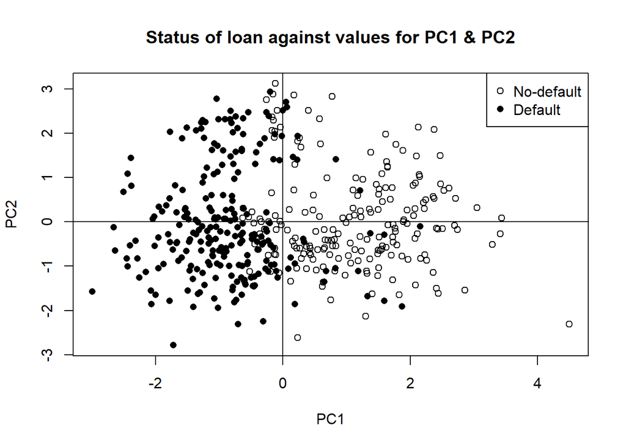

```r
# Plotting the scores for the first and second components
plot(datatyp_pca$PC1, datatyp_pca$PC2,pch=ifelse(datatyp_pca$loan_status == 0,1,16),xlab="PC1", ylab="PC2", main="Status of loan against values for PC1 & PC2")
abline(h=0)
abline(v=0)
legend("topright", legend=c("No-default","Default"), pch=c(1,16))
```

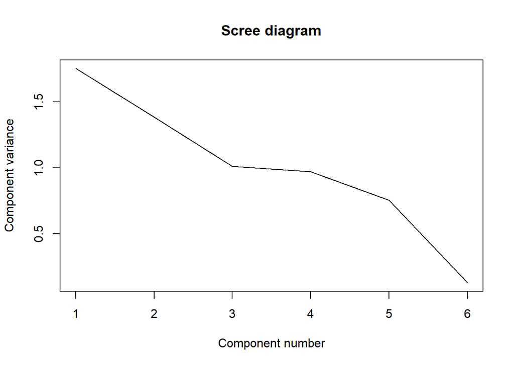

```r
plot(eigen_data, xlab = "Component number", ylab = "Component variance", type = "l", main = "Scree diagram")
```

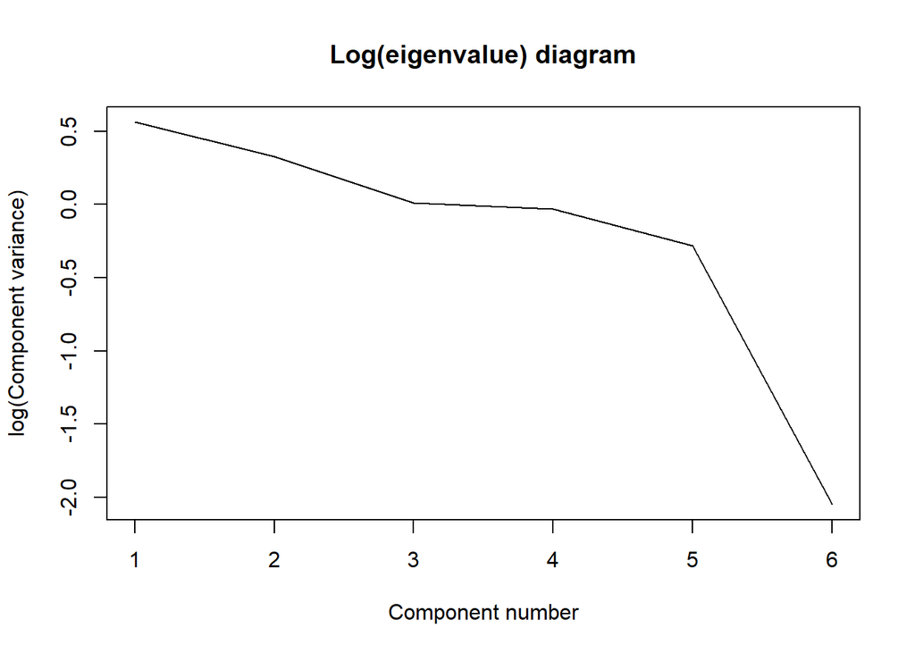

```r
plot(log(eigen_data), xlab = "Component number",ylab = "log(Component variance)", type="l",main = "Log(eigenvalue) diagram")
```

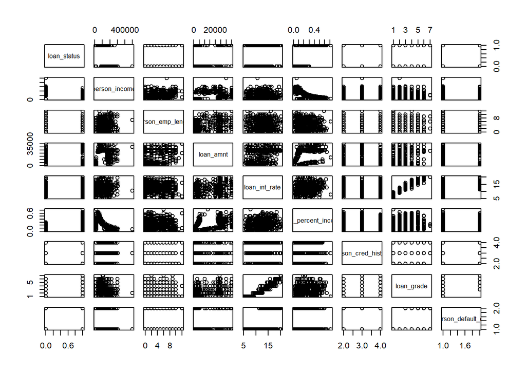

```r
plot(dataset[,-1])
```

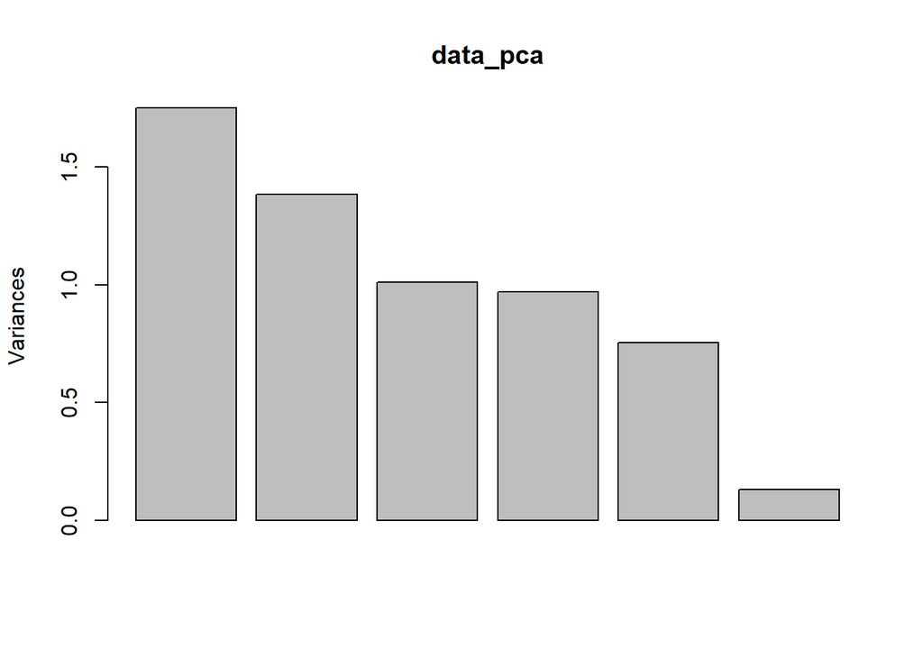

```r
plot(data_pca)
```

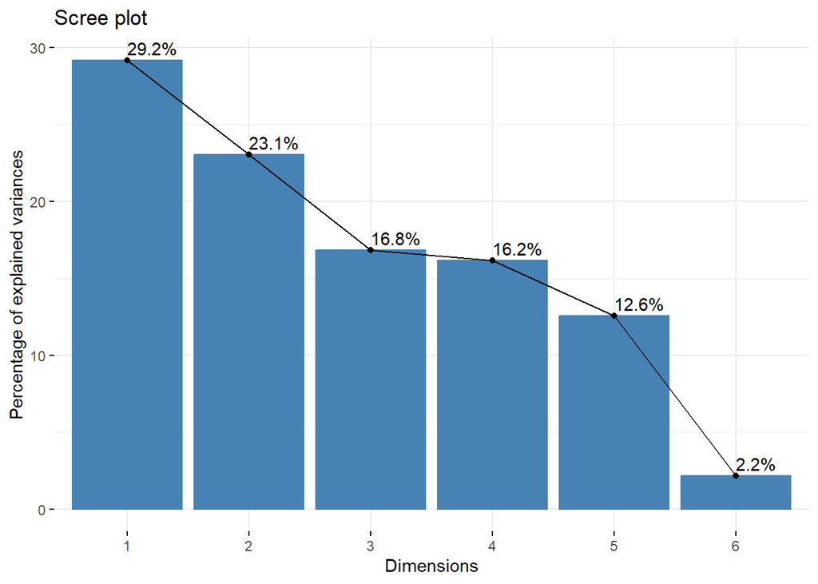

```r
library(factoextra)
fviz_eig(data_pca, addlabels = TRUE)
```

```r
library(FactoMineR)
library(ggfortify)
library(psych)
```

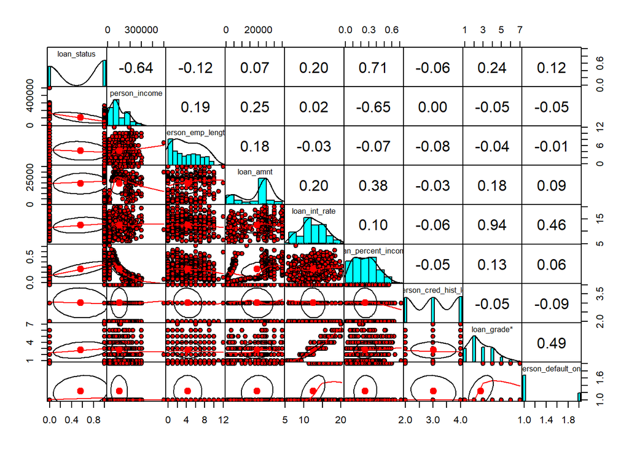

```r
library(corrplot)
library(devtools)
pairs.panels(dataset[,-1],
             gap = 0,
             bg = c("red", "blue")[dataset$loan_status],
             pch=21)
```

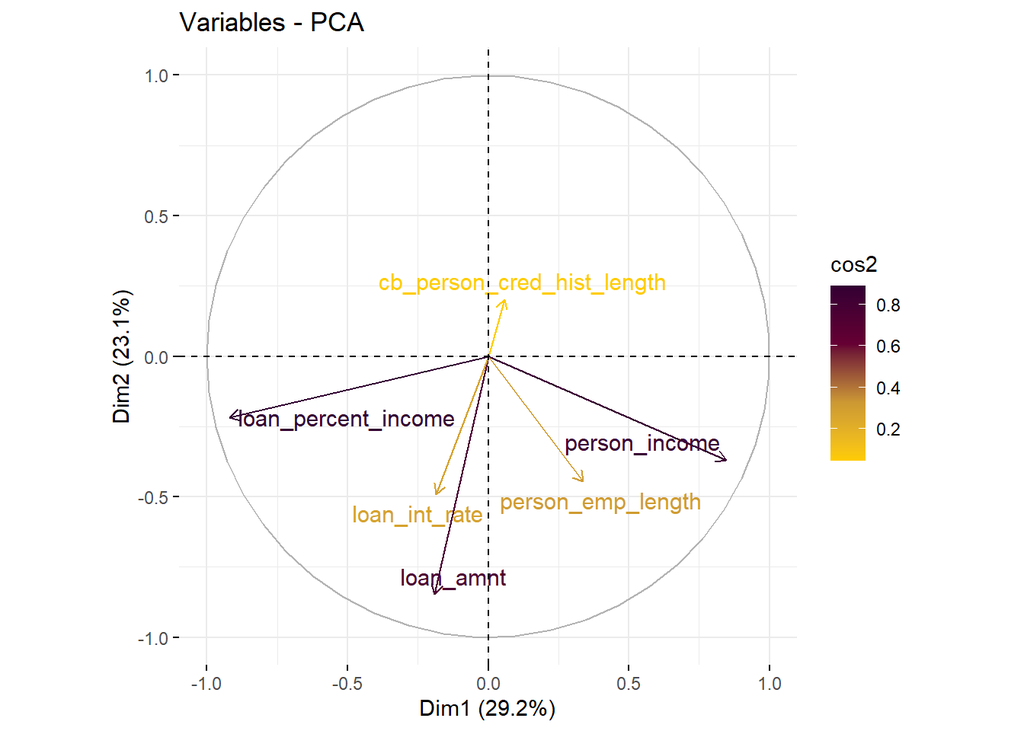

```r
fviz_pca_var(data_pca,col.var = "cos2",
             gradient.cols = c("#FFCC00", "#CC9933", "#660033", "#330033"),
             repel = TRUE)
```